# Workflow Multiple Models

Bruce Hartman

University of St. Francis

2026-08-12 Revised 2026-10-10T22:06:33

Abstract

We present some techniques for multiple models using `tidymodels` modeling workflow.

# Introduction

This notebook is designed to show how to use `tidymodels` workflow for multiple models you wish to compare.

One of the reasons for developing workflows is to make sure you use exactly the same conditions on each model in order to compare one with another.

# Packages

We use the standard packages and `tidymodels`.

```r
library(ISLR2)
library(mbadtools) # preferred packages for course
```

# Data

We use the `Bikeshare` data from ISLR2.

```r
Bikeshare %>% skim
```

```
── Data Summary ────────────────────────
                           Values
Name                       Piped data
Number of rows             8645
Number of columns          15
_______________________
Column type frequency:
  factor                   3
  numeric                  12
________________________
Group variables            None
```

|  | skim_variable | n_missing | complete_rate | ordered | n_unique | top_counts |
| --- | --- | --- | --- | --- | --- | --- |
| 1 | mnth | 0 | 1 | FALSE | 12 | May: 744, Jul: 744, Oct: 743, Dec: 741 |
| 2 | hr | 0 | 1 | FALSE | 24 | 16: 365, 17: 365, 12: 364, 13: 364 |
| 3 | weathersit | 0 | 1 | FALSE | 4 | cle: 5645, clo: 2218, lig: 781, hea: 1 |

|  | skim_variable | n_missing | complete_rate | mean | sd | p0 | p25 | p50 | p75 | p100 | hist |
| --- | --- | --- | --- | --- | --- | --- | --- | --- | --- | --- | --- |
| 1 | season | 0 | 1 | 2.51359167 | 1.1054769 | 1.00 | 2.0000 | 3.0000 | 3.0000 | 4.0000 | ▇▇▁▇▇ |
| 2 | day | 0 | 1 | 184.39572007 | 104.8233399 | 1.00 | 94.0000 | 185.0000 | 275.0000 | 365.0000 | ▇▇▇▇▇ |
| 3 | holiday | 0 | 1 | 0.02764604 | 0.1639660 | 0.00 | 0.0000 | 0.0000 | 0.0000 | 1.0000 | ▇▁▁▁▁ |
| 4 | weekday | 0 | 1 | 3.01272412 | 2.0063700 | 0.00 | 1.0000 | 3.0000 | 5.0000 | 6.0000 | ▇▃▃▃▇ |
| 5 | workingday | 0 | 1 | 0.68374783 | 0.4650395 | 0.00 | 0.0000 | 1.0000 | 1.0000 | 1.0000 | ▃▁▁▁▇ |
| 6 | temp | 0 | 1 | 0.48906883 | 0.1979434 | 0.02 | 0.3200 | 0.5000 | 0.6600 | 0.9600 | ▂▇▇▇▂ |
| 7 | atemp | 0 | 1 | 0.46900045 | 0.1767598 | 0.00 | 0.3182 | 0.4848 | 0.6212 | 1.0000 | ▂▆▇▆▁ |
| 8 | hum | 0 | 1 | 0.64342973 | 0.1962933 | 0.00 | 0.4900 | 0.6500 | 0.8100 | 1.0000 | ▁▃▇▇▆ |
| 9 | windspeed | 0 | 1 | 0.19117226 | 0.1231912 | 0.00 | 0.1045 | 0.1940 | 0.2836 | 0.8507 | ▇▆▂▁▁ |
| 10 | casual | 0 | 1 | 28.60057837 | 38.8407888 | 0.00 | 3.0000 | 14.0000 | 38.0000 | 272.0000 | ▇▁▁▁▁ |

[output cut: 2 more lines]

# Research Problem

We want to find a good model to predict the number of bikers, given all the other variables. We will try some esoteric AI type models.

# Models to consider

Some models to consider are a random forest, a neural net, and a decision tree. You can find the `tidymodels` possible models [at the parsnip website](https://www.tidymodels.org/find/parsnip/).

- Random forest using `ranger` [website](https://parsnip.tidymodels.org/reference/details_rand_forest_ranger.html)
- Bagged neural network using `nnet` [website](https://parsnip.tidymodels.org/reference/details_bag_mlp_nnet.html)
- Bagged trees via `rpart` [website](https://parsnip.tidymodels.org/reference/details_bag_tree_rpart.html)

Bagging is a so called ensemble technique, in which the basic model is run multiple times (the bagging) and then the outputs are ‘averaged’ to get the fitted result. Random forest itself contains multiple random trees that are then combined to get the predictions.

# Design

We want to train models on a part of the dataset, and evaluate them on the test dataset. Because we are using complex models with lots of parameters, we create a 5-fold CV data partition to tune the parameters on.

# Data Preparation

We perform a Crossvalidation split. Split the data into training and test datasets. We use an 80-20 split performed with the `rsample` package in `tidyverse`.

```r
set.seed(2026)
split <- initial_split(Bikeshare, prop = 0.8, strata = bikers)  # `bikers` is the outcome
train_data <- training(split)
test_data  <- testing(split)
folds      <- vfold_cv(train_data, v = 5)
```

# Recipe

The recipe creates the formula and the data in a standard manner. It’s like defining the formula and data. It also allows some modification such as scaling and removing variables with little variance, that is, that are almost constant and therefore unable to affect anything.

Most AI models work better with numeric predictors centered/scaled. Any model we choose predicts `bikers` using all other variables, and uses the training data. We’ll validate it on the test data later on.

In a recipe we only provide a dataset so the formula names can be recognized.

```r
bikeshare_recipe <- recipe(bikers ~ ., data = train_data) %>%
  step_nzv(all_predictors()) # remove near-zero variance variables if any

rec_basic <- bikeshare_recipe

rec_normalized <- bikeshare_recipe %>%
  step_normalize(all_numeric_predictors()) # center & scale numeric predictors
```

# Models

For random forest we will tune ‘mtry’ and ‘min_n’ parameters.

```r
rf_spec <- rand_forest(
  mode = "regression",
  mtry = tune(),        # number of predictors sampled at each split
  min_n = tune(),       # minimum data points in a node
  trees = 1000          # keep high for stability
) %>% set_engine("ranger", importance = "permutation")

params <-
  tribble(
    ~parameter, ~object,
    "mtry", mtry(),
    "min_n", min_n()
  )
complete_params <- params %>%
  mutate(object = map(object, finalize, select(Bikeshare, -bikers)))
```

Needed for bagging methods.

```r
library(baguette) # needed for bagging
```

Bagged neural net has parameters ‘penalty’ and ‘hidden_units’ for tuning.

```r
bag_nn_spec <- bag_mlp(penalty = tune(),
                       hidden_units = tune()
                       ) %>%
  set_engine("nnet") %>%
  set_mode("regression") %>%
  translate()

# Create a grid using dials functions (grid_regular, grid_random)
# dials supplies default ranges for hidden_units() and penalty() automatically
bag_mlp_grid <- grid_regular(extract_parameter_set_dials(bag_nn_spec))
bag_mlp_grid
```

| hidden_units | penalty |
| --- | --- |
| 1 | 1e-10 |
| 5 | 1e-10 |
| 10 | 1e-10 |
| 1 | 1e-05 |
| 5 | 1e-05 |
| 10 | 1e-05 |
| 1 | 1e+00 |
| 5 | 1e+00 |
| 10 | 1e+00 |

Bagged `rpart` tree has parameters ‘tree_depth’, ‘min_n’, and ‘cost_complexity’ for tuning.

```r
bag_tree_rpart_spec <- bag_tree(
    tree_depth = tune(),
    min_n = tune(),
    cost_complexity = tune()
  )  %>%
  set_engine("rpart") |>
  set_mode("regression") |>
  translate()

# Create a grid using dials functions (grid_regular, grid_random)
# dials supplies default ranges for hidden_units() and penalty() automatically
bag_tree_rpart_grid <- grid_regular(extract_parameter_set_dials(bag_tree_rpart_spec))
bag_tree_rpart_grid
```

| cost_complexity | tree_depth | min_n |
| --- | --- | --- |
| 1.000000e-10 | 1 | 2 |
| 3.162278e-06 | 1 | 2 |
| 1.000000e-01 | 1 | 2 |
| 1.000000e-10 | 8 | 2 |
| 3.162278e-06 | 8 | 2 |
| 1.000000e-01 | 8 | 2 |
| 1.000000e-10 | 15 | 2 |
| 3.162278e-06 | 15 | 2 |
| 1.000000e-01 | 15 | 2 |
| 1.000000e-10 | 1 | 21 |

[output cut: 17 more lines]

# Workflow Set

For multiple models run at once we use the `workflowset` package and create a workflow set.

```r
wf_set <- workflow_set(
  preproc = list(rec_basic, rec_normalized),
  models  = list(rf = rf_spec,
                 nn = bag_nn_spec,
                 dt = bag_tree_rpart_spec),
  cross = TRUE # Cross-combines all recipes with all models
)
```

# Tune All Models with Resamples

```r
set.seed(123)
# Fit every workflow in the set across all CV folds
tictoc::tic() # start runtime timer
wf_results <- wf_set %>%
  workflow_map("tune_grid", resamples = folds)
tictoc::toc() # stop timer and print runtime
```

```
3461.33 sec elapsed
```

```r
wf_results
```

| wflow_id | info | option | result |
| --- | --- | --- | --- |
| recipe_1_rf |  |  |  |
| recipe_1_nn |  |  |  |
| recipe_1_dt |  |  |  |
| recipe_2_rf |  |  |  |
| recipe_2_nn |  |  |  |
| recipe_2_dt |  |  |  |

# Rank and Compare Model Performance

```r
collect_metrics(wf_results)
```

| wflow_id | .config | preproc | model | .metric | .estimator | mean | n | std_err |
| --- | --- | --- | --- | --- | --- | --- | --- | --- |
| recipe_1_rf | pre0_mod01_post0 | recipe | rand_forest | rmse | standard | 44.5206484 | 5 | 0.9327441152 |
| recipe_1_rf | pre0_mod01_post0 | recipe | rand_forest | rsq | standard | 0.9351125 | 5 | 0.0031351458 |
| recipe_1_rf | pre0_mod02_post0 | recipe | rand_forest | rmse | standard | 22.0694827 | 5 | 0.8178564719 |
| recipe_1_rf | pre0_mod02_post0 | recipe | rand_forest | rsq | standard | 0.9802744 | 5 | 0.0011077776 |
| recipe_1_rf | pre0_mod03_post0 | recipe | rand_forest | rmse | standard | 9.6848349 | 5 | 0.4141787082 |
| recipe_1_rf | pre0_mod03_post0 | recipe | rand_forest | rsq | standard | 0.9957033 | 5 | 0.0002548808 |
| recipe_1_rf | pre0_mod04_post0 | recipe | rand_forest | rmse | standard | 6.4184467 | 5 | 0.3500086411 |
| recipe_1_rf | pre0_mod04_post0 | recipe | rand_forest | rsq | standard | 0.9979713 | 5 | 0.0001905174 |
| recipe_1_rf | pre0_mod05_post0 | recipe | rand_forest | rmse | standard | 6.3363581 | 5 | 0.4175407777 |
| recipe_1_rf | pre0_mod05_post0 | recipe | rand_forest | rsq | standard | 0.9979786 | 5 | 0.0002342543 |

[output cut: 110 more lines]

```r
# Rank models by performance (e.g., RMSE)
rank_results(wf_results, rank_metric = "rmse", select_best = TRUE)
```

| wflow_id | .config | .metric | mean | std_err | n | preprocessor | model | rank |
| --- | --- | --- | --- | --- | --- | --- | --- | --- |
| recipe_2_rf | pre0_mod09_post0 | rmse | 3.0724117 | 0.3356941722 | 5 | recipe | rand_forest | 1 |
| recipe_2_rf | pre0_mod09_post0 | rsq | 0.9994611 | 0.0001109009 | 5 | recipe | rand_forest | 1 |
| recipe_1_rf | pre0_mod09_post0 | rmse | 3.0731177 | 0.3350967590 | 5 | recipe | rand_forest | 2 |
| recipe_1_rf | pre0_mod09_post0 | rsq | 0.9994630 | 0.0001106350 | 5 | recipe | rand_forest | 2 |
| recipe_2_dt | pre0_mod04_post0 | rmse | 4.3281370 | 0.2356247633 | 5 | recipe | bag_tree | 3 |
| recipe_2_dt | pre0_mod04_post0 | rsq | 0.9989510 | 0.0001087130 | 5 | recipe | bag_tree | 3 |
| recipe_1_dt | pre0_mod04_post0 | rmse | 4.3312884 | 0.2378721626 | 5 | recipe | bag_tree | 4 |
| recipe_1_dt | pre0_mod04_post0 | rsq | 0.9989493 | 0.0001097001 | 5 | recipe | bag_tree | 4 |
| recipe_2_nn | pre0_mod10_post0 | rmse | 9.0304501 | 0.2699629932 | 5 | recipe | bag_mlp | 5 |
| recipe_2_nn | pre0_mod10_post0 | rsq | 0.9957257 | 0.0002906825 | 5 | recipe | bag_mlp | 5 |

[output cut: 2 more lines]

# Plot performance comparisons visually

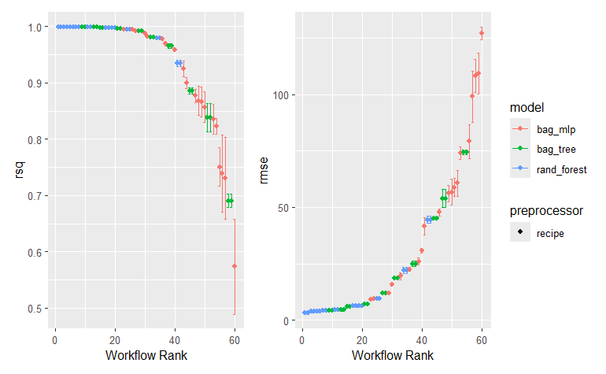

```r
wrap_plots(
  list(autoplot(wf_results, metric = "rsq"),
       autoplot(wf_results, metric = "rmse")
      ), ncol=2, guides='collect')
```

Random forest clearly did the best.

```r
rank_results(wf_results, rank_metric = "rmse", select_best = TRUE)[1,]
```

| wflow_id | .config | .metric | mean | std_err | n | preprocessor | model | rank |
| --- | --- | --- | --- | --- | --- | --- | --- | --- |
| recipe_2_rf | pre0_mod09_post0 | rmse | 3.072412 | 0.3356942 | 5 | recipe | rand_forest | 1 |

# Extract and Fit Best Model

Once you pick the winning workflow, extract and finalize it on the whole training set:

```r
# Extract a specific workflow (e.g., "")
best_wf <- extract_workflow(wf_results, id = "recipe_2_rf")

# Extract the best hyperparameters for that specific workflow
best_params <- select_best(
  extract_workflow_set_result(wf_results, id = "recipe_2_rf"),
  metric = "rmse"
)

# Finalize the workflow with best hyperparameter values
final_wf <- finalize_workflow(best_wf, best_params)

# Fit on 100% of data and evaluate on test_data
tictoc::tic()
final_fit <- last_fit(final_wf, split)
tictoc::toc()
```

```
19.25 sec elapsed
```

```r
# View test set metrics (e.g., RMSE, R-squared)
collect_metrics(final_fit)
```

| .metric | .estimator | .estimate | .config |
| --- | --- | --- | --- |
| rmse | standard | 2.186539 | pre0_mod0_post0 |
| rsq | standard | 0.999741 | pre0_mod0_post0 |

# Predictions

Make predictions for 1731 test rows. We know the rmse for these is 2.18, very low.

```r
collect_predictions(final_fit, summarize=TRUE) %>%
  arrange(.row)
```

| .pred | bikers | .row | .config |
| --- | --- | --- | --- |
| 6.023311 | 6 | 28 | pre0_mod0_post0 |
| 1.188939 | 1 | 31 | pre0_mod0_post0 |
| 64.413518 | 65 | 41 | pre0_mod0_post0 |
| 22.044581 | 22 | 44 | pre0_mod0_post0 |
| 5.013802 | 5 | 48 | pre0_mod0_post0 |
| 30.332718 | 30 | 52 | pre0_mod0_post0 |
| 51.608548 | 51 | 57 | pre0_mod0_post0 |
| 61.080045 | 61 | 58 | pre0_mod0_post0 |
| 157.254306 | 157 | 64 | pre0_mod0_post0 |
| 183.375290 | 179 | 77 | pre0_mod0_post0 |

[output cut: 990 more lines]

# Conclusion

We have shown how to handle fitting and testing three models with various parameter settings. The random forest with ‘mtry=11’ and ‘min_n=10’ gave the best results. This is shown well in Figure 1 above. The tuning parameters are shown below.

```r
# Extract all tuning results for recipe_2_rf and filter by the winning .config
collect_metrics(extract_workflow_set_result(wf_results, id = "recipe_2_rf")) %>%
  filter(.config == "pre0_mod09_post0") %>%
  distinct(mtry, min_n, .config)
```

| mtry | min_n | .config |
| --- | --- | --- |
| 11 | 10 | pre0_mod09_post0 |

# References

Kuhn et al., (2020). Tidymodels: a collection of packages for modeling and machine learning using tidyverse principles. (https://www.tidymodels.org)

Search parsnip models, (n.d.) (https://www.tidymodels.org/find/parsnip/)

Explore tidymodels, (n.d.) (https://www.tidymodels.org/find/)